# Lab 7: Multiple linear regression into

Alia Ajina

11/9/2021

## Explore penguins

Use `GGally::ggpairs()` to create pairs plot.

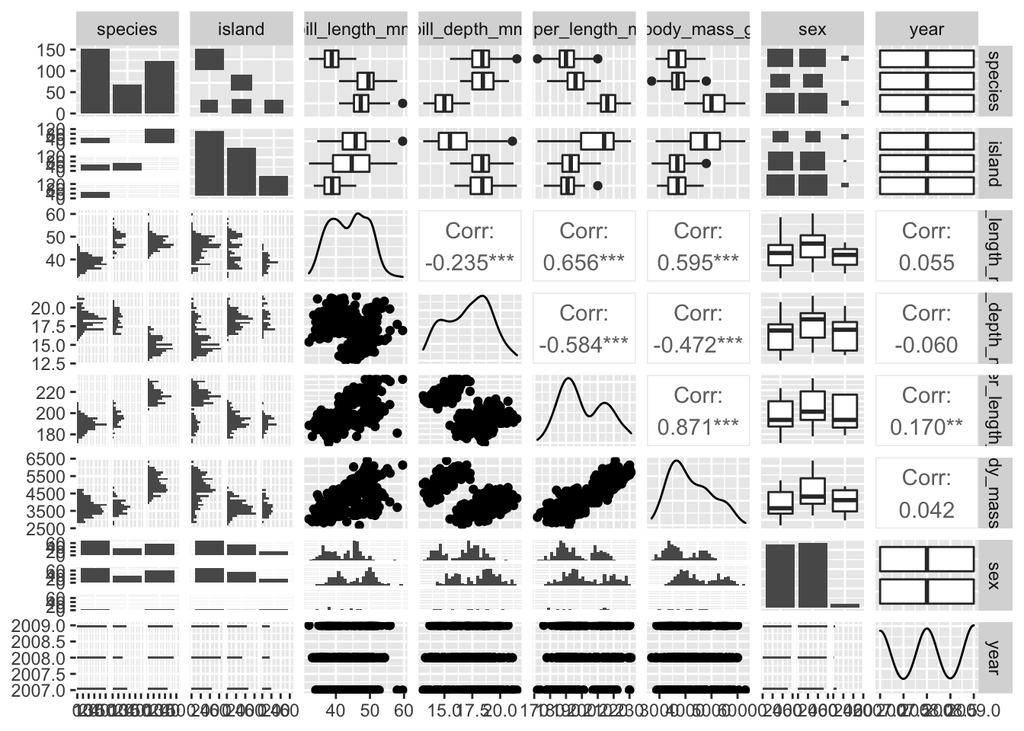

```r
ggpairs(penguins)
```

That’s kind of overkill. Let’s simplify the variables that we include in our ggpairs plot:

- species
- bill_length_mm through body_mass_g

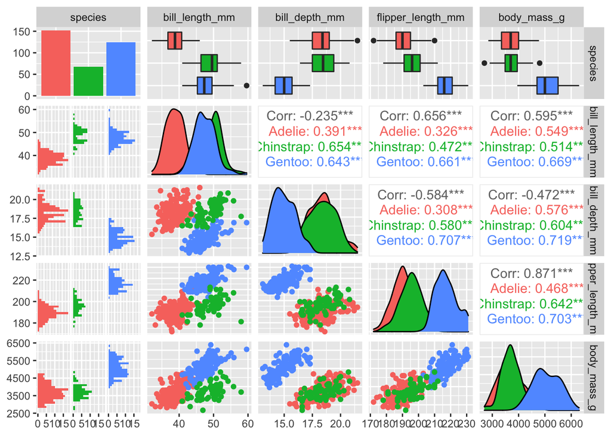

```r
penguins %>%
  select(species, bill_length_mm:body_mass_g) %>%
  ggpairs(aes(color = species))
```

Quick way to look at multi-variable comparisons and add some groupings ^^

## Multiple linear regression

We are going to try to understand (a bit better) relationships between multiple predictor variables and an outcome which is penguin body mass.

The different predcitor variables we’re going to try are:

- species
- flipper length
- sex
- bill depth

They should be grounded in some understanding of the impacts of these different variables on body mass but we’re just going to try some different options

### Model 1

Model body mass based on only flipper length and bill depth (bad idea… there are important variables missing, ie sex)

(a model running is not a good indication of success for modeling)

(tilde = as a function of…)

```r
model_1 <- lm(body_mass_g ~ flipper_length_mm + bill_depth_mm, data = penguins)

# Call model by name to return only coefficients:
model_1
```

```
##
## Call:
## lm(formula = body_mass_g ~ flipper_length_mm + bill_depth_mm,
##     data = penguins)
##
## Coefficients:
##       (Intercept)  flipper_length_mm      bill_depth_mm
##          -6541.91              51.54              22.63
```

or "If everything else is held constant, we expect that for each 1mm increase in flipper length, penguin body mass is expected to increase by 51.54 g, on average. <- remember to use inline code